# Assignment 6

2024-03-06

There are two goals for this assignment: (1) to get you introduced to predictive models in R, and (2) to get thinking critically about fairness, bias, and to evaluate claims around fairness and bias. We’ll pay particular attention to what **input data** we use to `train` predictive models, as well as the types of **errors** that the models make.

There is **no code** that you have to write in this assignment! Of course, feel free to play around, but please focus on giving **written answers to the questions in bold text** (between two *’s in this .Rmd file)

## # Part 1: Predicting the future - exploring the COMPAS data

During the Lab, we discussed the COMPAS Risk Assessment tool, an algorithm published by Northpointe (now [Equivant](https://www.equivant.com/)), that assigns a **Risk Score** (1-10) that predicts how likely an individual is to commit another crime (to re-offend or recidivate; low score = low risk, high score = high risk). Northpointe ran their own analyses to validate their algorithm, and they claim that it fairly and accurately predicts recidivism.

We also looked at an investigation into the fairness and accuracy of COMPAS by the independent news outlet [ProPublica](https://www.propublica.org/article/machine-bias-risk-assessments-in-criminal-sentencing), who claimed that the algorithm is racially-biased: Black individuals are more often to receive a higher score but not re-offend, whereas White individuals are more likely to be given a low score, but actually re-offend. It’s important to note that this refers to *the algorithm’s errors* - i.e., the way it makes mistakes is not equal across groups.

In their investigation, ProPublica obtained and analyzed COMPAS data regarding 7,214 individuals in Broward County, Florida. Their dataset and analysis are [publicly available online](https://www.propublica.org/datastore/dataset/compas-recidivism-risk-score-data-and-analysis). We’ll use this dataset to evaluate the claims of both Northpointe and ProPublica. They can’t both be right … can they?

First, please watch the intro to this [YouTube Video](https://www.youtube.com/watch?v=TqnYf2h6A-k). For now, just watch up to 2:32 (2 minutes, 32 seconds). **What feelings/emotions do you get from Kevin’s introduction to algorithmic prediction of recidivism? Or, what kinds of emotions do you think Kevin is trying to elicit? How many followers/subscribers does his channel (Vsauce2) have?**

— Your answers here —

Let’s start by getting a handle on the data used in ProPublica’s investigation. As usual, we’ll set up our workspace by installing packages that we don’t have already, and loading them into `R` using `library()`. The packages we’ll use are `ggplot2`, `randomForest`, and `tree`. Install what you don’t have by running `install.packages(c('ggplot2','randomForest','tree'))`. If you run into any issues installing, try updating to the latest version of `R`.

```r
rm(list = ls()) # Fresh start! This clears your Environment
library(ggplot2)
library(randomForest)
library(tree)
```

Download and extract the COMPAS dataset `propub_compas.csv` used by ProPublica from Courseworks. Load it into R using `read.csv()`, as usual. Inspect the first 10 rows of the data frame using `head()`.

Note: in the table that displays, you can click the arrows in the top-right and top-left to navigate across the columns.

```r
# Read in the CSV file
compas_raw = read.csv('propub_compas.csv')

# Inspect the first 10 rows to get a sense of the structure
head(compas_raw, 10)
```

```
##    id               name     first        last compas_screening_date    sex
## 1   1   miguel hernandez    miguel   hernandez            2013-08-14   Male
## 2   3        kevon dixon     kevon       dixon            2013-01-27   Male
## 3   4           ed philo        ed       philo            2013-04-14   Male
## 4   5        marcu brown     marcu       brown            2013-01-13   Male
## 5   6 bouthy pierrelouis    bouthy pierrelouis            2013-03-26   Male
## 6   7       marsha miles    marsha       miles            2013-11-30   Male
## 7   8      edward riddle    edward      riddle            2014-02-19   Male
## 8   9     steven stewart    steven     stewart            2013-08-30   Male
## 9  10   elizabeth thieme elizabeth      thieme            2014-03-16 Female
## 10 13          bo bradac        bo      bradac            2013-11-04   Male
##           dob age         age_cat             race juv_fel_count decile_score
## 1  1947-04-18  69 Greater than 45            Other             0            1
## 2  1982-01-22  34         25 - 45 African-American             0            3
## 3  1991-05-14  24    Less than 25 African-American             0            4
```

[output cut: 117 more lines]

**How many ROWS and COLUMNS are in the dataframe `compas_raw`? What does each ROW represent?**

— Your answers here —

Many of these columns are not going to be useful for prediction, such as each person’s name. Let’s do some data wrangling/cleaning which will make for cleaner code and analyses later. So that we can compare results to what ProPublica found, we’ll limit analyses to a subset of the data (for example, we’ll only keep rows where the defendant was `Caucasian` or `African-American` for `race`).

To ensure we’re all working with the same data subset, the wrangling code is provided below. It may look like a lot, but please take a few minutes to study it (but no longer than a few minutes). There’s nothing below that you couldn’t do on your own at this point. And, you will likely want/need to do some similar tasks for your own project - so hopefully this may be a useful reference.

The result of the chunk below is a new dataframe `compas` that is a subset of `compas_raw` that you created above. I’ve left comments (lines that start with a `#`) to section off what’s happening – get in the habit of commenting your own code!!

```r
# --- Compute total time in jail from in and out dates (store in a new column)
compas_raw$jailtime = as.Date(compas_raw$c_jail_out) - as.Date(compas_raw$c_jail_in)

# --- Select relevant columns (to keep)
# Notice we're pulling columns from 'compas_raw' here, to make 'compas'
compas = compas_raw[,c('sex',
              'age_cat',
              'race',
              'juv_fel_count',
              'juv_misd_count',
              'juv_other_count',
              'priors_count',
              'c_charge_degree',
              'jailtime',
              'decile_score',
              'score_text',
              'is_recid')]

# --- Rename columns (here, order matters!)
# Notice we're now renaming cols in 'compas' -- 'compas_raw' is no longer used
colnames(compas) = c('sex',
                'age',
                'race',
                'juv_fel',
                'juv_misd',
                'juv_other',
                'priors',
                'crime',
                'jailtime',
                'score',
                'score_cat',
                'recid')

# --- Rename some factor levels for convenience
compas$race[compas$race == 'African-American'] = 'Black'
compas$race[compas$race == 'Caucasian'] = 'White'
compas$age[compas$age == 'Less than 25'] = 'Under 25'
compas$age[compas$age == 'Greater than 45'] = 'Over 45'

# --- Only keep rows where race is white or black, like ProPublica
compas = compas[compas$race == 'White' | compas$race == 'Black', ]

# --- Remove any rows with NA in any column - Random Forests cannot handle NA
# This only removes ~30-ish rows where 'jailtime' wasn't recorded and is NA
compas = compas[complete.cases(compas), ]

# --- Make column types explicit (mainly factors and numbers)
compas$sex = as.factor(compas$sex)
# NOTE: using factor() with the 'levels' argument specifies the ORDER of levels - handy for plotting
compas$age = factor(compas$age, levels = c('Under 25','25 - 45','Over 45'))
compas$race = as.factor(compas$race)
compas$crime = as.factor(compas$crime)
compas$jailtime = as.numeric(compas$jailtime)
compas$score_cat = as.factor(compas$score_cat)
compas$recid = as.factor(compas$recid)

# --- Preview the now-cleaned and -wrangled dataframe
head(compas, 10)
```

```
##       sex      age  race juv_fel juv_misd juv_other priors crime jailtime score
## 2    Male  25 - 45 Black       0        0         0      0     F       10     3
## 3    Male Under 25 Black       0        0         1      4     F        1     4
## 7    Male  25 - 45 White       0        0         0     14     F        6     6
## 9  Female  25 - 45 White       0        0         0      0     M        3     1
## 10   Male Under 25 White       0        0         0      1     F        1     3
## 11   Male  25 - 45 White       0        0         0      0     F        1     4
## 12   Male Under 25 Black       0        0         0      3     M        4     6
## 13 Female  25 - 45 White       0        0         0      0     M        1     1
## 14   Male  25 - 45 Black       0        0         0      0     F        1     4
## 15 Female  Over 45 White       0        0         0      1     F       14     1
##    score_cat recid
## 2        Low     1
## 3        Low     1
## 7     Medium     1
## 9        Low     0
## 10       Low     1
## 11       Low     0
## 12    Medium     1
## 13       Low     0
## 14       Low     0
## 15       Low     1
```

You should now have a dataframe called `compas` with 5915 rows and 12 columns. Take a look at `compas` by clicking its name in your Environment or looking through the output of `head()` above (again, scroll right and left to see all variables). **What do you think it means if `recid` is `0` or if it’s `1`? What do `F` and `M` stand for in the `crime` variable? What is the relationship between `score` and `score_cat`? (Qualitative answers here - no need to write code; spoilers are below but I’m more interested in what you think at this point)**

- When `recid` is `0`, it means:
- when `recid` is `1`, it means:
- When `crime` is `M`, it stands for:
- When `crime` is `F`, it stands for:
- The relationship between `score` and `score_cat` is:

Seriously, try answering before moving on! (I want you to exercise your intuition on what a column contains…)

OK, SPOILER ALERT, so we’re all on the same page: `recid` is `0` if the person did NOT recidivate in a 2-year span post-COMPAS assessment, and `recid` is `1` if they DID recidivate in that timeframe. The variable `crime` is `M` for a misdemeanor, and `F` for a felony - the crime the person was arrested for at COMPAS assessment. The variable `score` is the **risk score** assigned to that person by COMPAS, and `score_cat` is a **risk category** that corresponds to the `score`. You would be correct to say that `score` and `score_cat` are directly correlated. (`score_cat` is just a low-resolution, chunky version of `score`).

One of ProPublica’s main claims is that COMPAS scores are racially-biased. Let’s begin evaluating this by replicating one their key figures - a histogram that shows the distributions of **risk scores** by race. The figure should show the number of individuals in the dataset at each level of risk score (1-10). So, we’ll have 10 positions on the x-axis (one for each `score` level), with a bar for each, and the height of the bar will represent the number of individuals with that score.

The plotting code is below (but again, nothing here you couldn’t do on your own!):

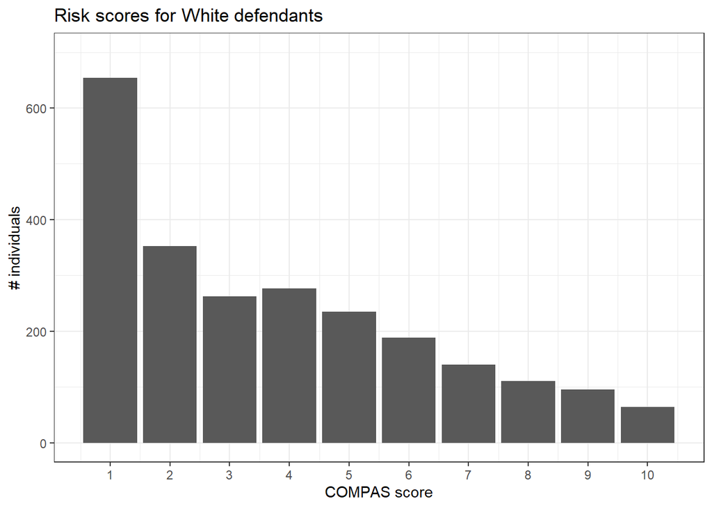

```r
# --- (1) For White defendants --------- #
ggplot(compas[compas$race == 'White',]) +
  aes(x = score) +
  geom_bar() +
  ylim(c(0,700)) + # Set y-axis limits; useful for comparing multiple plots
  scale_x_continuous(breaks = 1:10) + # This puts tick marks at each number 1-10
  theme_bw() +
  labs(title = 'Risk scores for White defendants',
       x = 'COMPAS score',
       y = '# individuals')
```

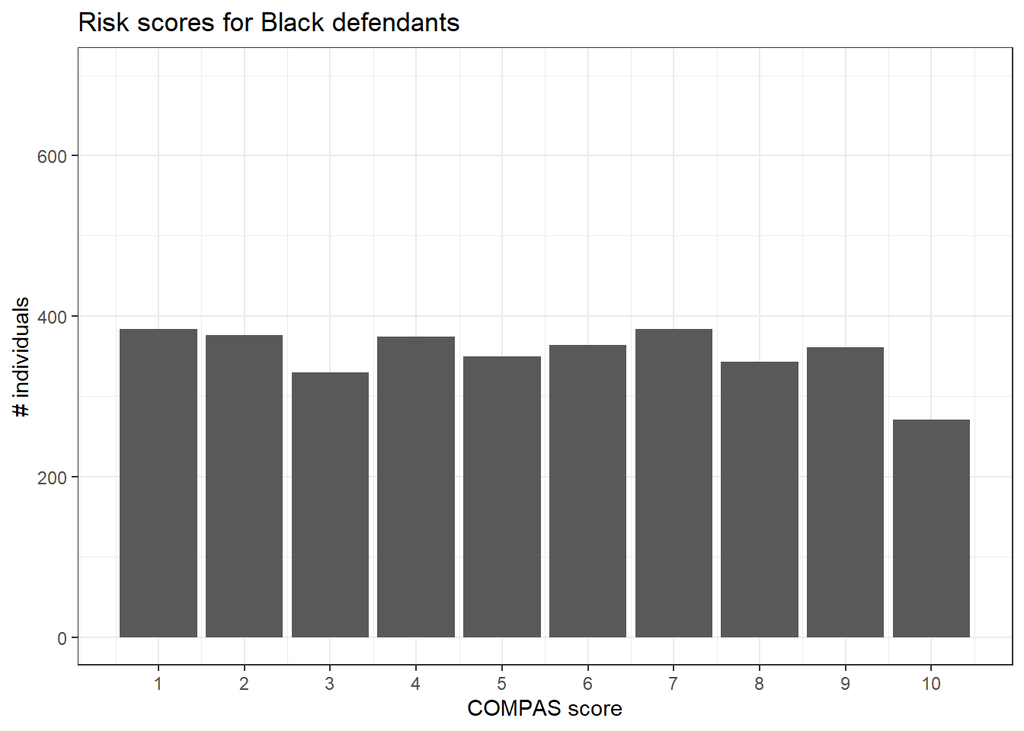

```r
# --- (2) For Black defendants --------- #
ggplot(compas[compas$race == 'Black',]) +
  aes(x = score) +
  geom_bar() +
  ylim(c(0,700)) +
  scale_x_continuous(breaks = 1:10) +
  theme_bw() +
  labs(title = 'Risk scores for Black defendants',
       x = 'COMPAS score',
       y = '# individuals')
```

**What differences do you see in the histograms of COMPAS scores for `White` and `Black` defendants? Do these differences show evidence that the COMPAS algorithm is racially-biased? Why or why not? (If you are unsure, tell me what more information you’d like to know)**

— Your answer here —

These histograms do not show anything about who actually recidivates. This is important, because it’s possible that differences in risk scores may be due to differences in baseline rates of recidivism, or what are generally called “base rates”. In Bayesian statistics, these are called “prior probabilities”, or just “priors”.

So, let’s plot risk scores by both `race` and recidivism. We could use a line plot, but I think a “heatmap” would be appropriate here. A heatmap is a type of plot, usually organized as a 2D grid, where the intensity of color represents data values. They are useful especially when `x` and `y` axes are categorical.

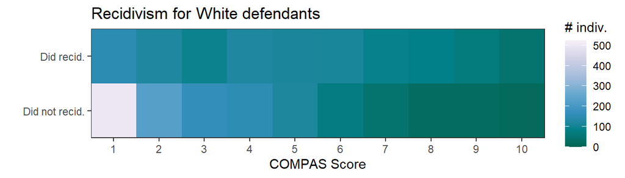

```r
# --------- Plot risk scores and recidivism --------- #

# First create a data frame containing the frequency of intent by race
# This basically makes a 2D "histogram"
sub_compas = compas[compas$race == 'White',]
t = data.frame(table(sub_compas$score, sub_compas$recid))

# Plot it as a heatmap
ggplot(t) +
  aes(Var1, Var2, fill = Freq) +
  geom_tile() +
  scale_x_discrete(expand = c(0,0)) +
  scale_y_discrete(labels = c('Did not recid.', 'Did recid.'),
                   expand = c(0,0)) +
  labs(title = 'Recidivism for White defendants',
       x = 'COMPAS Score',
       y = '') +
  theme_bw() +
  scale_fill_distiller(name = '# indiv.', palette = 'PuBuGn', limits = c(0,525))
```

[figure not shown]

```r
# -------------------------------------------------- #

sub_compas = compas[compas$race == 'Black',]
t = data.frame(table(sub_compas$score, sub_compas$recid))

ggplot(t) +
  aes(Var1, Var2, fill = Freq) +
  geom_tile() +
  scale_x_discrete(expand = c(0,0)) +
  scale_y_discrete(labels = c('Did not recid.', 'Did recid.'),
                   expand = c(0,0)) +
  labs(title = 'Recidivism for Black defendants',
       x = 'COMPAS Score',
       y = '') +
  theme_bw() +
  scale_fill_distiller(name = '# indiv.', palette = 'PuBuGn', limits = c(0,525))
```

**What differences do you see in the two heatmaps above? Does it appear that the COMPAS score captures something about the likelihood of actual recidivism? (no right or wrong answers here)**

— Your description here —

## # Part 2: Predicting the future - training a predictive model

Now, the point of the COMPAS risk scores is to predict whether an individual will or will not recidivate. Because we know the `ground truth` (who actually did and did not recidivate), we can train a predictive model using a `supervised` algorithm.

Training models to make predictions in R can actually be quite easy and straightforward. As in, one-line-of-code easy. Of course, we might be interested in the actual predictive value of the model (who cares HOW it makes decisions, as long as it’s correct often enough), but we can also use it to investigate the relationships between outcomes (here, recidivism) and predictors (the rest of the variables). Here, we’ll use Random Forests because they are `supervised` models that are easy to train and interpret. They can also be remarkably accurate and generalizable; this is bona fide machine learning!

Before we go on, we should get a grip on how Random Forest models work. Forests are made of trees (decision trees) - so let’s take a look at a single decision tree grown from this data set. It’s unfortunately difficult to visualize one tree with the `randomForest` package, but we can with `tree`, which you installed and library’d above. Run the code below to visualize a single decision tree that predicts recidivism.

NOTE: We aren’t using all variables to predict `recid` below, just `priors`, `jailtime`, `age`, `sex`, and `race`. Read the formula below like `Y = X1 + X2 + X3 + X4` where `Y` is what we want to predict (recidivism), and `X1, X2, X3, X4` are the variables used to make the prediction (prior offenses, jail time, age, sex, and race). The goal of modeling is to find out how the `X's` relate to the `Y`.

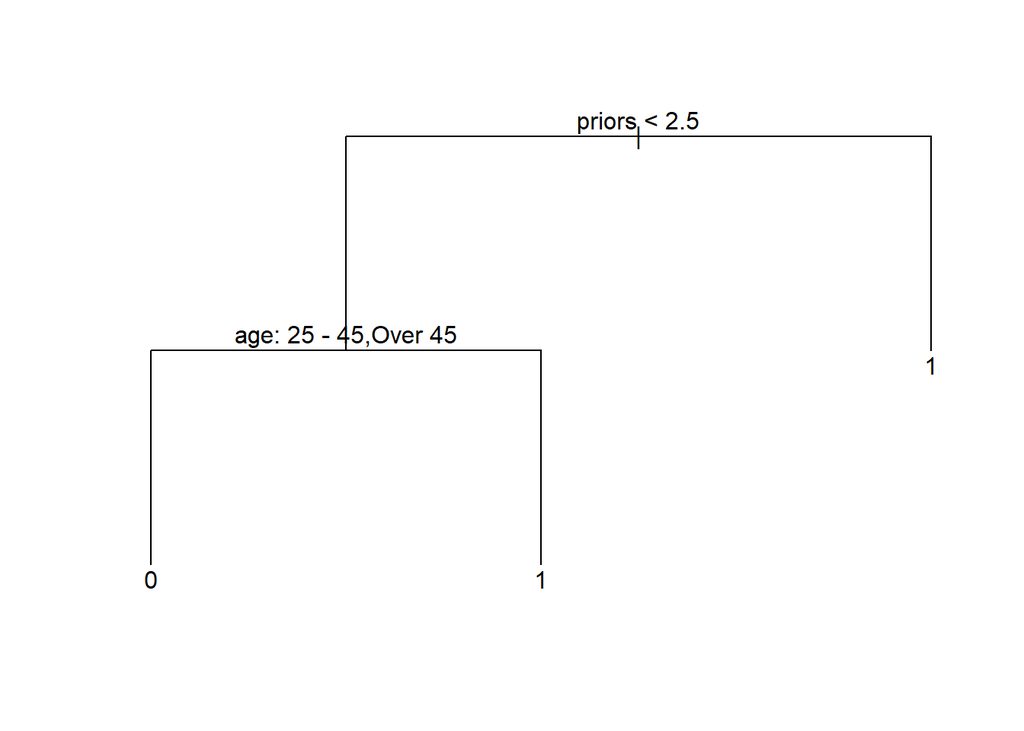

```r
tr = tree(recid ~ priors + jailtime + age + sex + race, data = compas)
plot(tr, type = 'uniform')
text(tr, pretty = 0)
```

Study the decision tree above. **Which variable is involved in the first decision - at the tree’s “root”? The labels tell you on what condition to move “left” on the tree (otherwise, move right). Fill in the [] boxes below with `1` or `0` based on the tree.**

Root variable:

- If `priors` is `> 2.5` the individual is class: []
- If `priors` is `< 2.5`
  - and `age` is `Under 25` the individual is class: []
  - and `age` is `25 -45` or `Over 45` the individual is class: []

**Fill in the blanks to summarize the tree:** — If you have ____ (few/many) prior offenses and are ____ (over/under) 25 years old, you are unlikely to re-offend —

The `type = 'uniform'` argument to `plot()` above draws the branches of equal length on the tree, whereas `type = proportional` makes the lengths proportional to how influential that decision was during model training. **Change the plot type to ‘proportional’ above and re-run the code chunk. Which decision is more important - `priors` or `age`?**

— Your answer here —

This tree alone is probably not a good classifier. If it performs slightly better than random guessing, we call it a “weak learner”. Random Forests are a type of ensemble method, where many weak learners are combined to produce a single prediction. Even if individuals (single Trees) make decisions slightly better than random guessing, as a group they can reach near-perfect accuracy ([See here for more](https://en.wikipedia.org/wiki/Condorcet%27s_jury_theorem)). Luckily it’s very easy to train a Random Forest in R. The basic code to do so is below – run the chunk and we’ll inspect the results.

NOTE: The way to read the formula is the same as above, except the `.` means “all variables in the dataframe except `Y`”. It can be a convenient shorthand as long as you’ve made sure to remove columns that you don’t want (like we did in the wrangling chunk in Part 1).

```r
rf = randomForest(recid ~ ., data = compas)
rf # call the variable by its name to see the output
```

```
##
## Call:
##  randomForest(formula = recid ~ ., data = compas)
##                Type of random forest: classification
##                      Number of trees: 500
## No. of variables tried at each split: 3
##
##         OOB estimate of  error rate: 32.54%
## Confusion matrix:
##      0    1 class.error
## 0 2055  844   0.2911349
## 1 1081 1935   0.3584218
```

Inspect the output above. The overall error rate is the OOB (out-of-bag) estimate of error rate. Check the confusion matrix to see where the model makes mistakes. The ROWS are the true class labels (recidivated or not), and the COLUMNS are what the model predicted. So, the diagonal of the confusion matrix (upper-left and lower-right) are instances where the model made correct predictions. The corners (upper-right and lower-left) are **errors** - and the type of error is not the same. When the prediction is `0` but the truth is `1`, the error is a `false negative`. When the prediction is `1` but the truth is `0`, the error is a `false positive`. You can view the rates of these types of errors in the `class.error` column of the confusion matrix. **Fill out the numbers below based on the model summary above.**

- Model error = [] %
- Accuracy = 100% - model error = [] %
- False positive rate: true 0, predicted 1 = [] %
- False negative rate: true 1, predicted 0 = [] %

**Put into your own words what it means when `recid` is predicted `1` but is truly `0`; and when `recid` is predicted `0` but is truly `1`. Is one of these predictions more ‘severe’ than the other?**

— Your answer here —

Without getting into detail, the data resampling process during random forest training has a useful byproduct - variable importance. Variable importance can help explain the data by indicating HOW the classes separate, i.e., which variables were *most predictive* of recidivism. (By classes, I mean where `recid` is `1` or `0` - two classes) **Run the function varImpPlot(), passing in your random forest model as the only argument.** The “MeanDecreaseGini” is a weird name, but we won’t get into it - it’s a relative scale so all that matters is the points relative to each other (higher values = more important).

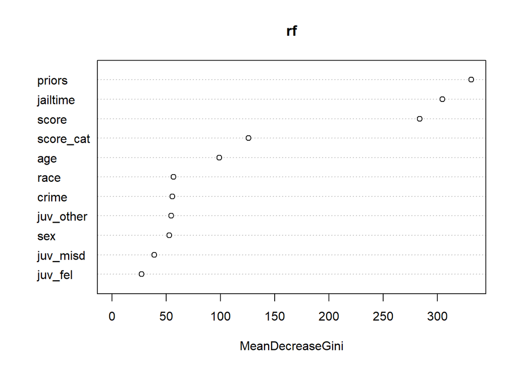

```r
varImpPlot(rf)
```

**According to the plot, what are the top 3 variables that are most informative for predicting recidivism? What are the 3 least important?**

— Your description here —

If the COMPAS score has some predictive value for recidivism, it should be “important” in the plot above. Interestingly, there are other variables that are also important, if not more so than the COMPAS score. Let’s compare predicting recidivism with the other important variables without `score`, versus predictions using `score` alone.

```r
# Train a model using a subset of other variables
randomForest(recid ~ priors + jailtime + age, data = compas)
```

```
##
## Call:
##  randomForest(formula = recid ~ priors + jailtime + age, data = compas)
##                Type of random forest: classification
##                      Number of trees: 500
## No. of variables tried at each split: 1
##
##         OOB estimate of  error rate: 32.92%
## Confusion matrix:
##      0    1 class.error
## 0 2009  890   0.3070024
## 1 1057 1959   0.3504642
```

Now use only the COMPAS score to predict `recid`:

```r
# Train a model using only the COMPAS risk score
randomForest(recid ~ score, data = compas)
```

```
##
## Call:
##  randomForest(formula = recid ~ score, data = compas)
##                Type of random forest: classification
##                      Number of trees: 500
## No. of variables tried at each split: 1
##
##         OOB estimate of  error rate: 34.35%
## Confusion matrix:
##      0    1 class.error
## 0 1938  961   0.3314936
## 1 1071 1945   0.3551061
```

**Compare the overall error rate (OOB estimate) of the first model with that of the second. In the first, you did not use the COMPAS score. In the second, that is all that you used.**

- Model error using `priors`, `jailtime`, and `age` = [] %
- Model error using only `score` = [] %

… wait. What!? You should have found that the OOB error rates for both models are eerily similar. But you used completely different types of **input data** to train the two models. **How is this possible!? (again no right or wrong answers here)**

— Your speculation here —

## Part 3: Evaluating fairness and bias using random forests

ProPublica’s main claim is that the COMPAS predictions are racially biased. Northpointe claims ProPublica is wrong. ProPublica rebuts Northpointe’s accusation. Check out the “Controversies” section on the Machine Learning Fairness Wikipedia page for some links to the back-and-forth between ProPublica and Northpointe (if you want). We’re not going to resolve the debate here, but we can use it as a springboard for discussing what it means for an algorithm to be “fair”.

To start, we’ll need to assess model performance by subgroup (i.e. `race`) from this particular model. It would be VERY handy if we could organize the error types into a table or figure, so that we could compare the performance of different models. We can write code to get those numbers, but we might like to re-use that same code several times. To accomplish this, we’re going to write our first custom `R` **function**. We’re not going to go deep into custom functions in this course, but I wanted you to see an example. The function `getPredictionError()` below will take in as arguments a `model` and a `dataframe` (it doesn’t matter what their names are), and will spit back (or `return`) a table with model performance measures organized by `race`. This function will work exactly like other `R` functions, for example: `mean()`, that takes arguments (a list of numbers) and returns a value (a single number, the average of the input numbers).

Because we’re making this function ourselves, we can’t use it until you run the code chunk below. Go ahead:

```r
getPredictionError = function(model, dataframe)
{
  # This function assumes the dataframe has columns 'recid' and 'race'
  # and that 'race' has the levels 'Black' and 'White'
  preds = predict(model, dataframe)
  recid = dataframe$recid
  race = dataframe$race

  t = table(recid, preds, race)

  t[,,'Black'] = t[,,'Black'] / sum(t[,,'Black'])
  t[,,'White'] = t[,,'White'] / sum(t[,,'White'])

  t = as.data.frame(t)
  t$type = NA
  for (i in 1:nrow(t))
  {
    if (t[i,'recid'] == 0 & t[i,'preds'] == 0) {
      t[i,'type'] = 'true neg'
    } else if (t[i,'recid'] == 1 & t[i,'preds'] == 1) {
      t[i,'type'] = 'true pos'
    } else if (t[i,'recid'] ==  0 & t[i,'preds'] == 1) {
      t[i,'type'] = 'false pos'
    } else if (t[i,'recid'] ==  1 & t[i,'preds'] == 0) {
      t[i,'type'] = 'false neg'
    }
  }
  t$type = as.factor(t$type)

  # Total % errors
  # These lines print to the console for convenience!
  print('Total error for Black defendants:')
  print(sum(t[t$race == 'Black' & grepl('false', t$type), 'Freq']))
  print('Total error for White defendants:')
  print(sum(t[t$race == 'White' & grepl('false', t$type), 'Freq']))

  print('Error ratio for Black defendants:')
  print(t[t$race == 'Black' & t$type == 'false pos', 'Freq'] / t[t$race == 'Black' & t$type == 'false neg', 'Freq'])
  print('Error ratio for White defendants:')
  print(t[t$race == 'White' & t$type == 'false pos', 'Freq'] / t[t$race == 'White' & t$type == 'false neg', 'Freq'])

  return(t)
}
```

When you run it - you should not see any output, in either this .Rmd or the `R` console. **Instead, you should see something new in your Environment. What new object entered your Environment, and what “header” is it under? (hint: it should be the bottom-most object in the Environment panel)**

— Your answer here —

You can now run this function any time, inputting any model you train and any dataset:

```r
getPredictionError(rf, compas)
```

```
## [1] "Total error for Black defendants:"
## [1] 0.1826407
## [1] "Total error for White defendants:"
## [1] 0.1980656
## [1] "Error ratio for Black defendants:"
## [1] 0.7650273
## [1] "Error ratio for White defendants:"
## [1] 0.2015306
```

```
##   recid preds  race       Freq      type
## 1     0     0 Black 0.35510319  true neg
## 2     1     0 Black 0.10347752 false neg
## 3     0     1 Black 0.07916313 false pos
## 4     1     1 Black 0.46225615  true pos
## 5     0     0 White 0.53994954  true neg
## 6     1     0 White 0.16484441 false neg
## 7     0     1 White 0.03322119 false pos
## 8     1     1 White 0.26198486  true pos
```

You should have two “pages” of output above, (1) some printed statements from the R Console output, and (2) a view of a new dataframe with true values of `recid`, predicted values in `preds`, `race`, and `Freq` which is the proportion for each group `Black` and `White`, and `type` which labels the type of error (`false pos` and `false neg`) or correct prediction (`true pos` and `true neg`).

In the Console printout, the `Total error` for each group is just the sum of `false pos` and `false neg` - whenever the predictions were wrong. The `Error ratio` however, is the ratio of `false pos` to `false neg`. It’s greater than 1 if you have more `false pos` than `false neg`, and it’s less than 1 if you have fewer `false pos` than `false neg` errors.

The difference in Error ratios between `Black` and `White` defendants is the crux of ProPublica’s claim for racial bias in COMPAS scores. This may become more clear with a visual. Run the code below that trains a new Random Forest on COMPAS scores alone, organizes the model predictions by `race` and `type`, and plots the result. It also plots a horizontal line at the overall error rate of the model - this is mainly to use as a reference, and, if it looks too high, imagine stacking the black and gray bars on top of each other in cases of `false neg` and `false pos`.

```r
rf = randomForest(recid ~ score, data = compas)
rf
```

```
##
## Call:
##  randomForest(formula = recid ~ score, data = compas)
##                Type of random forest: classification
##                      Number of trees: 500
## No. of variables tried at each split: 1
##
##         OOB estimate of  error rate: 34.35%
## Confusion matrix:
##      0    1 class.error
## 0 1938  961   0.3314936
## 1 1071 1945   0.3551061
```

```r
t = getPredictionError(rf, compas)
```

```
## [1] "Total error for Black defendants:"
## [1] 0.3471869
## [1] "Total error for White defendants:"
## [1] 0.3380992
## [1] "Error ratio for Black defendants:"
## [1] 1.124567
## [1] "Error ratio for White defendants:"
## [1] 0.6308316
```

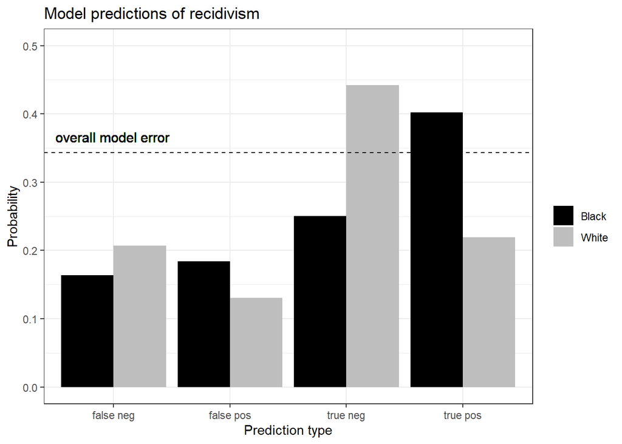

```r
ggplot(t) +
  aes(x = type, y = Freq, fill = race) +
  geom_bar(stat = 'identity', position = 'dodge') +
  geom_hline(yintercept = mean(rf$err.rate), linetype = 'dashed', color = 'black') +
  geom_text(aes(0.5, mean(rf$err.rate), label = 'overall model error', vjust = -1, hjust = 0), size = 4) +
  theme_bw() +
  ylim(c(0,0.5)) +
  labs(title = 'Model predictions of recidivism',
       x = 'Prediction type',
       y = 'Probability') +
  scale_fill_discrete(name = '', type = c('black', 'grey'))
```

**What’s the difference in total error (false pos + false neg) for Black and White defendants? What are the Error Ratios (false pos / false neg) for Black and White defendants? (get these from the Console output, not the plot)**

- Total error difference (`Black`-`White`): []
- Error Ratio for Black defendants: []
- Error Ratio for White defendants: []

**Does the difference in total error support Northpointe’s claim that the algorithm predicts recidivism similarly accurately for Black and White defendants? Do the Error Ratios support ProPublica’s claim that rates of false positives and false negatives are different for Black and White defendants?**

— Your answer here —

One criterion for algorithmic “fairness” that people discuss is called **Error ratio parity**, meaning that the Error ratios should be the same when comparing groups (i.e. `Black` vs `White`, or `Male` vs `Female`). If they aren’t, there is a dis-parity. There are ways to force Error ratio parity on the model, but we’ll get into that another time.

Maybe there’s something else we can do to make the algorithm more “fair”, since we do have some control over what **input data** go into model training. Another criterion is called **Demographic parity** or, vaguely, “statistical parity”, in which an outcome (here, did or did not recidivate) is equally likely across groups, **even if** base rates in the population actually do differ. We could “force” Demographic parity onto the model by selecting a sub-sample of the original data in which equal numbers of `Black` and `White` defendants do and do not recidivate:

```r
# Told you we'd keep coming back to logical indexing ;)
# Below we're just grabbing a random sample of 1000 row numbers
# for each combination of 'race' and 'recid'
idx1 = sample(which(compas$race == 'Black' & compas$recid == 1), 1000, replace = FALSE)
idx2 = sample(which(compas$race == 'Black' & compas$recid == 0), 1000, replace = FALSE)
idx3 = sample(which(compas$race == 'White' & compas$recid == 1), 1000, replace = FALSE)
idx4 = sample(which(compas$race == 'White' & compas$recid == 0), 1000, replace = FALSE)

# Combine them all at the end
idx = c(idx1, idx2, idx3, idx4)

# If you're curious, take a look at idx - it is not TRUE/FALSE like usual,
# instead it's the actual row numbers that come from which()
# Use idx now to get a subset of 'compas'
compas_parity = compas[idx,]
```

Now train a new random forest model, and plot the prediction outcomes using the `getPredictionError()` function we wrote above:

```r
rf = randomForest(recid ~ score, data = compas_parity)
rf
```

```
##
## Call:
##  randomForest(formula = recid ~ score, data = compas_parity)
##                Type of random forest: classification
##                      Number of trees: 500
## No. of variables tried at each split: 1
##
##         OOB estimate of  error rate: 35.45%
## Confusion matrix:
##      0    1 class.error
## 0 1339  661      0.3305
## 1  757 1243      0.3785
```

```r
t = getPredictionError(rf, compas_parity)
```

```
## [1] "Total error for Black defendants:"
## [1] 0.3515
## [1] "Total error for White defendants:"
## [1] 0.3575
## [1] "Error ratio for Black defendants:"
## [1] 1.565693
## [1] "Error ratio for White defendants:"
## [1] 0.4803313
```

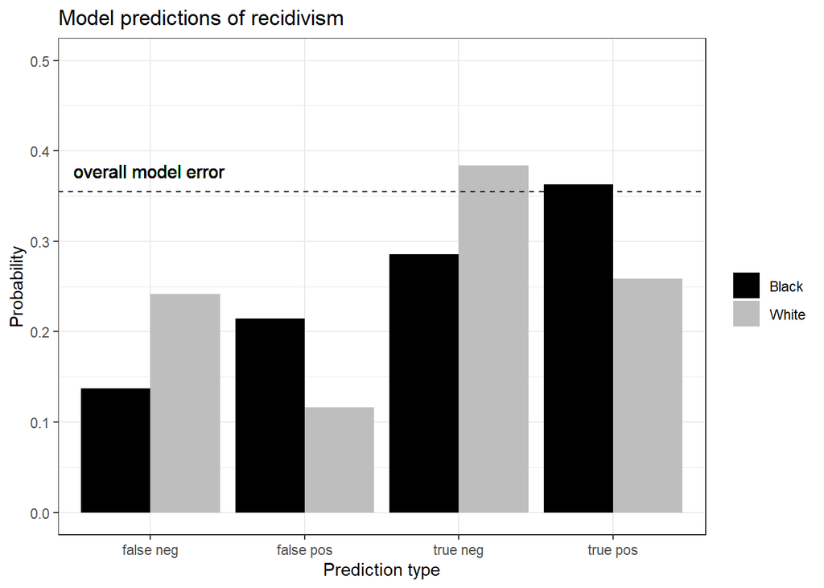

```r
ggplot(t) +
  aes(x = type, y = Freq, fill = race) +
  geom_bar(stat = 'identity', position = 'dodge') +
  geom_hline(yintercept = mean(rf$err.rate), linetype = 'dashed', color = 'black') +
  geom_text(aes(0.5, mean(rf$err.rate), label = 'overall model error', vjust = -1, hjust = 0), size = 4) +
  theme_bw() +
  ylim(c(0,0.5)) +
  labs(title = 'Model predictions of recidivism',
       x = 'Prediction type',
       y = 'Probability') +
  scale_fill_discrete(name = '', type = c('black', 'grey'))
```

**Compare this plot to the one above: What happened to the differences between Black and White individuals for TRUE predictions (negative and positive)? (Use the plots to answer this - did the heights of the bars get closer to each other?). Have the total error rates changed? How have the Error Ratios changed for Black and White individuals? Did they move closer or farther from 1 (equal rates)?**

— Your answers here —

A common theme in the literature around “fairness” and “bias” in predictive algorithms is this: when you adjust the model to be more fair in one direction, you necessarily become less fair AND/OR less accurate in other directions. Here, ensuring Demographic parity in recidivism led to MORE dis-parity in Error ratios - meaning the differences in types of errors were exacerbated!

This is all to say that seeking fair prediction algorithms is challenging and nuanced. This is not a realm of tried-and-true “right answers”. In cases such as this - we may be suspicious that there’s something deeper going on in the underlying data. I’ll leave you with an interesting [TED talk](https://www.youtube.com/watch?v=p-82YeUPQh0) that describes how a group of researchers did a lot of work on this same dataset using similar methods that you used in this assignment (optional viewing). They concluded that the source of bias may be in the data themselves - `Black` individuals are policed more heavily, thus are more likely to be arrested, thus their base rates for recidivism are higher than for `White` individuals. The algorithm itself is not biased of its own accord, but instead is picking up on existing social inequalities.

## Part 4: Your feedback

**On a scale of 1-5, with 1 being “too easy”, 5 being “too hard”, and 3 being “a good level”, how difficult was this assignment?**

**Approximately how much time did you spend working on this assignment? (i.e. actively solving the problem, not exploring the data independently)**

**Any thoughts on what you found useful, or what you found mundane, or confusing? (anything, big or small)**